# Project 7

Dinh Tran

Dec 06 2018

## 0.1 Description and Introduction

#### 0.1.0.1 Libraries

```r
library(cluster)
library(gridExtra)
library(factoextra)
```

```r
library(ggplot2)
library(tidyverse)
require(mclust)
```

#### 0.1.0.2 Dataset

This dataset was populated from destination reviews published by 249 reviewers of holidayiq.com till October 2014. Reviews falling in 6 categories among destinations across South India were considered and the count of reviews in each category for every reviewer (traveler) is captured.

##### 0.1.0.2.1 *Attribute Information:*

Attribute 1 : Unique user id Attribute 2 : Number of reviews on stadiums, sports complex, etc. Attribute 3 : Number of reviews on religious institutions Attribute 4 : Number of reviews on beach, lake, river, etc. Attribute 5 : Number of reviews on theatres, exhibitions, etc. Attribute 6 : Number of reviews on malls, shopping places, etc. Attribute 7 : Number of reviews on parks, picnic spots, etc.

```r
setwd("C:/Users/goodi/OneDrive/Desktop/CST 435/Project 7")
my_data<- read.csv("buddymove_holidayiq.csv", header = TRUE)

my_data1<- my_data %>% select(Sports, Religious,Nature)
my_data<-my_data %>% select(Sports,Religious)

my_data<- data.frame(na.omit(my_data))

#my_data<- lapply(my_data,as.numeric)
head(my_data)
```

```
##   Sports Religious
## 1      2        77
## 2      2        62
## 3      2        50
## 4      2        68
## 5      2        98
## 6      3        52
```

```r
summary(my_data)
```

```
##      Sports        Religious
##  Min.   : 2.00   Min.   : 50.0
##  1st Qu.: 6.00   1st Qu.: 84.0
##  Median :12.00   Median :104.0
##  Mean   :11.99   Mean   :109.8
##  3rd Qu.:18.00   3rd Qu.:132.0
##  Max.   :25.00   Max.   :203.0
```

## 0.2 Clustering

K-means clustering is the most commonly used unsupervised machine learning algorithm for partitioning a given data set into a set of k groups (i.e. k clusters), where k represents the number of groups pre-specified by the analyst. It classifies objects in multiple groups (i.e., clusters), such that objects within the same cluster are as similar as possible (i.e., high intra-class similarity), whereas objects from different clusters are as dissimilar as possible (i.e., low inter-class similarity). In k-means clustering, each cluster is represented by its center (i.e, centroid) which corresponds to the mean of points assigned to the cluster (https://uc-r.github.io/kmeans_clustering#elbow).

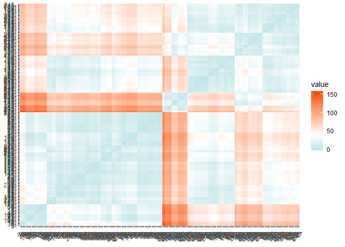

```r
distance <- get_dist(my_data)
fviz_dist(distance, gradient = list(low = "#00AFBB", mid = "white", high = "#FC4E07"))
```

#### 0.2.0.2 K-means methods

##### 0.2.0.2.1 *Using Elbow Method*

The basic idea behind cluster partitioning methods, such as k-means clustering, is to define clusters such that the total intra-cluster variation (known as total within-cluster variation or total within-cluster sum of square) is minimized

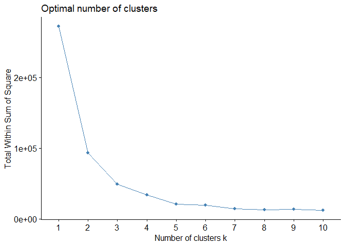

##### 0.2.0.2.2 *Gap statistic method*

The reference dataset is generated using Monte Carlo simulations of the sampling process. That is, for each variable (xi) in the data set we compute its range [min(xi),max(xj)] and generate values for the n points uniformly from the interval min to max.

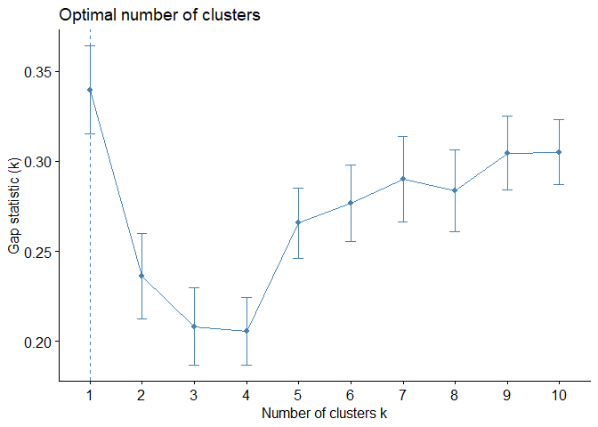

##### 0.2.0.2.3 *Silhouette*

The average silhouette approach measures the quality of a clustering. That is, it determines how well each object lies within its cluster. A high average silhouette width indicates a good clustering. The average silhouette method computes the average silhouette of observations for different values of k. The optimal number of clusters k is the one that maximizes the average silhouette over a range of possible values for k^2.

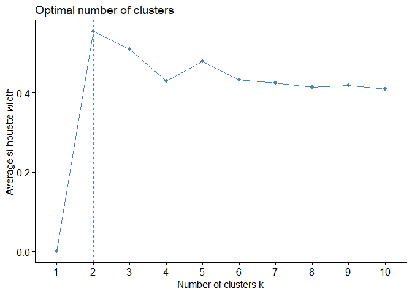

```r
fviz_nbclust(my_data, kmeans, method = "silhouette")
```

## 0.3 K-means for Sports and Religious

The first step when using k-means clustering is to indicate the number of clusters (k) that will be generated in the final solution. The algorithm starts by randomly selecting k objects from the data set to serve as the initial centers for the clusters. The selected objects are also known as cluster means or centroids. Next, each of the remaining objects is assigned to it’s closest centroid, where closest is defined using the Euclidean distance (Eq. 1) between the object and the cluster mean. This step is called “cluster assignment step”. After the assignment step, the algorithm computes the new mean value of each cluster. The term cluster “centroid update” is used to design this step. Now that the centers have been recalculated, every observation is checked again to see if it might be closer to a different cluster. All the objects are reassigned again using the updated cluster means. The cluster assignment and centroid update steps are iteratively repeated until the cluster assignments stop changing (i.e until convergence is achieved). That is, the clusters formed in the current iteration are the same as those obtained in the previous iteration (https://uc-r.github.io/kmeans_clustering#elbow).

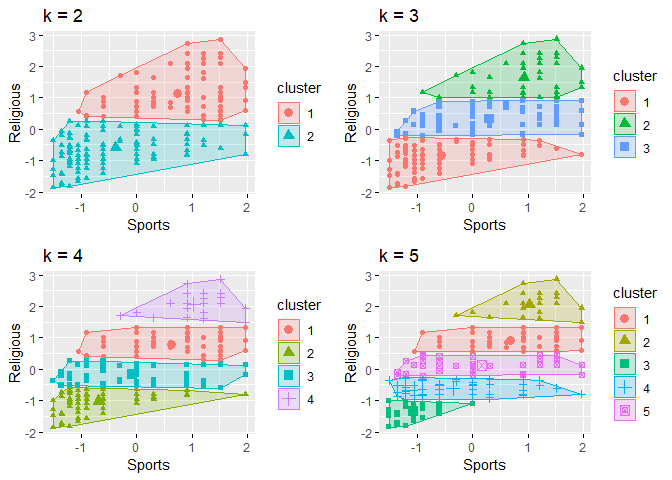

```r
k2 <- kmeans(my_data, centers = 2, nstart = 25)
k3 <- kmeans(my_data, centers = 3, nstart = 25)
k4 <- kmeans(my_data, centers = 4, nstart = 25)
k5 <- kmeans(my_data, centers = 5, nstart = 25)
k6 <- kmeans(my_data, centers = 6, nstart = 25)
k7 <- kmeans(my_data, centers = 7, nstart = 25)
k8 <- kmeans(my_data, centers = 8, nstart = 25)
k9 <- kmeans(my_data, centers = 9, nstart = 25)
k10 <- kmeans(my_data, centers = 10, nstart = 25)

p1 <- fviz_cluster(k2, geom = "point", data = my_data) + ggtitle("k = 2")
p2 <- fviz_cluster(k3, geom = "point",  data = my_data) + ggtitle("k = 3")
p3 <- fviz_cluster(k4, geom = "point",  data = my_data) + ggtitle("k = 4")
p4 <- fviz_cluster(k5, geom = "point",  data = my_data) + ggtitle("k = 5")
p5 <- fviz_cluster(k6, geom = "point",  data = my_data) + ggtitle("k = 6")
p6 <- fviz_cluster(k7, geom = "point",  data = my_data) + ggtitle("k = 7")
p7 <- fviz_cluster(k8, geom = "point",  data = my_data) + ggtitle("k = 8")
p8 <- fviz_cluster(k9, geom = "point",  data = my_data) + ggtitle("k = 9")
p9 <- fviz_cluster(k10, geom = "point",  data = my_data) + ggtitle("k = 10")
grid.arrange(p1, p2, p3, p4, nrow = 2)
```

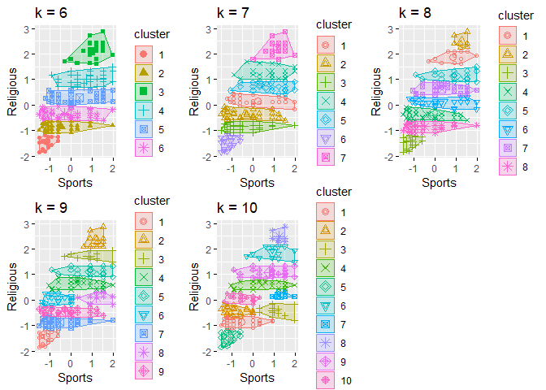

```r
grid.arrange(p5,p6,p7,p8,p9, nrow = 2)
```

## 0.4 Kmean Clustering for Sports, Religious and Nature

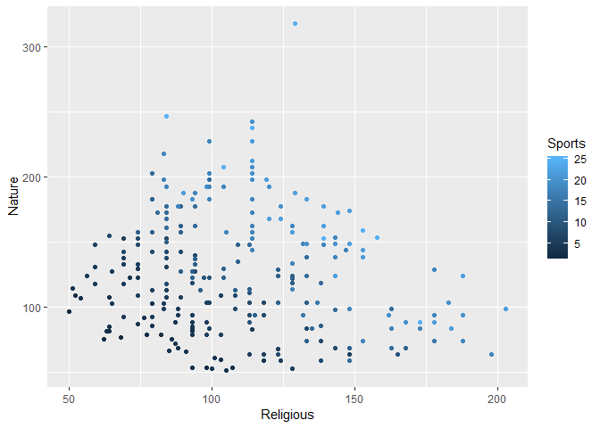

```r
#plot the kmeans for Religious and Nature between different Sports
ggplot(my_data1 , aes(Religious,Nature, color = Sports)) + geom_point()
```

```r
set.seed(20)

#Analyze Kmesn with 8 clusters
dataCluster <- kmeans(my_data1[,2:3],8,nstart = 20)
dataCluster
```

```
## K-means clustering with 8 clusters of sizes 25, 33, 40, 37, 7, 34, 28, 45
##
## Cluster means:
##   Religious    Nature
## 1 174.48000  88.00000
## 2 133.27273 155.15152
## 3  77.97500 136.87500
## 4 116.97297 111.72973
## 5 109.71429 247.14286
## 6  97.20588 188.73529
## 7 122.82143  65.57143
## 8  80.35556  90.95556
##
## Clustering vector:
##   [1] 8 8 8 8 7 8 8 8 8 8 7 7 8 7 8 8 3 3 8 7 8 7 3 3 8 8 3 7 3 8 3 8 7 8 8
##  [36] 8 8 3 8 8 3 8 8 8 8 3 7 7 8 8 7 8 8 8 3 4 8 3 7 8 4 3 3 8 4 8 7 4 4 4
##  [71] 7 3 3 3 3 7 3 7 4 7 3 7 7 3 8 4 3 7 8 3 7 3 8 3 8 8 4 7 3 8 7 8 4 3 8
## [106] 3 4 3 4 4 3 4 6 2 6 4 1 3 4 3 4 6 6 7 4 4 4 6 3 7 4 3 6 4 3 4 7 2 4 4
## [141] 4 4 2 1 3 4 3 4 7 3 6 6 6 4 4 3 4 6 7 4 1 2 1 6 6 1 2 6 1 2 6 2 6 6 2
## [176] 1 6 2 6 1 6 2 4 1 5 1 6 6 6 2 1 2 6 6 1 5 2 2 6 1 2 2 1 6 1 2 4 6 4 1
## [211] 4 5 1 1 1 6 2 1 6 6 6 2 2 2 1 6 2 1 2 2 2 1 2 6 2 5 1 3 2 2 1 5 6 5 2
## [246] 5 2 2 2
##
## Within cluster sum of squares by cluster:
## [1] 11126.240 11972.788 12533.350 11602.270  7442.286 12838.176 11020.964
## [8] 14990.222
##  (between_SS / total_SS =  88.0 %)
##
## Available components:
##
## [1] "cluster"      "centers"      "totss"        "withinss"
## [5] "tot.withinss" "betweenss"    "size"         "iter"
## [9] "ifault"
```

```r
#Compare cluster with Sports
table(dataCluster$cluster,my_data1$Sports)
```

```
##
##      2  3  4  5  6  8 10 12 14 16 18 20 22 25
##   1  0  0  0  0  0  0  1  2  2  1  8  6  4  1
##   2  0  0  0  0  0  0  0  1  2  0 12  4 11  3
##   3  0  0  2  8  5 15  0  9  1  0  0  0  0  0
##   4  0  0  0  0  3  8  4 15  3  2  1  0  1  0
##   5  0  0  0  0  0  0  0  0  0  0  1  1  2  3
##   6  0  0  0  0  0  0  0  4  8  0 11  6  4  1
##   7  1  3  4  2  7  5  0  4  2  0  0  0  0  0
##   8  4  8 13  8 11  1  0  0  0  0  0  0  0  0
```

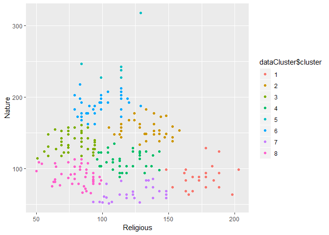

```r
dataCluster$cluster<-as.factor(dataCluster$cluster)
ggplot(my_data1,aes(Religious, Nature,color = dataCluster$cluster))+geom_point()
```

## 0.5 Expectation - Maximization

Using EM algorithm to find the Kmeans clustering for the data

```r
Sport<-my_data1$Sports
table(Sport)
```

```
## Sport
##  2  3  4  5  6  8 10 12 14 16 18 20 22 25
##  5 11 19 18 26 29  5 35 18  3 33 17 22  8
```

```r
X<- my_data1[,-1]
head(X)
```

```
##   Religious Nature
## 1        77     79
## 2        62     76
## 3        50     97
## 4        68     77
## 5        98     54
## 6        52    109
```

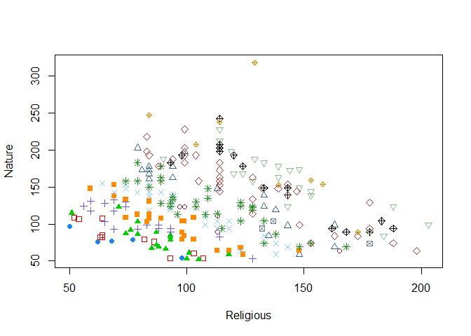

```r
clPairs(X, Sport)
```

```r
fit<-Mclust(X)
summary(fit)
```

```
## ----------------------------------------------------
## Gaussian finite mixture model fitted by EM algorithm
## ----------------------------------------------------
##
## Mclust EVV (ellipsoidal, equal volume) model with 4 components:
##
##  log.likelihood   n df       BIC       ICL
##        -2458.99 249 20 -5028.329 -5106.447
##
## Clustering table:
##  1  2  3  4
## 91 47 52 59
```

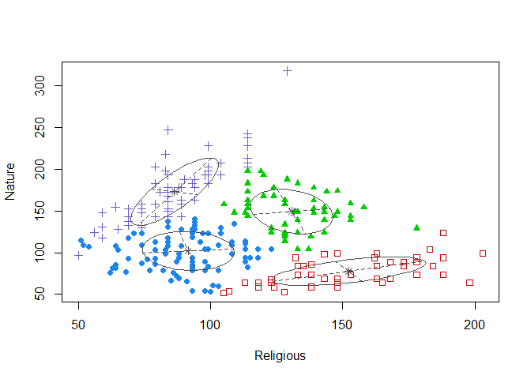

```r
#A plot of the classification uncertainty
plot(fit,what = "classification")
```

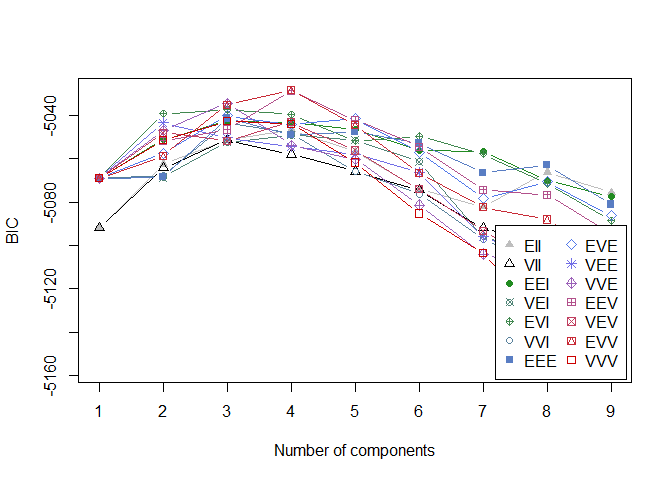

```r
# BIC values used for choosing the number of clusters
plot(fit, what = "BIC")
```

## 0.6 Conclusion

There are a lot of advantages from Kmeans Clustering in analyzing data. It is easy to implement, with a large number of variables, K-means may be computationally faster than hierarchical clustering. K-means may produce tighter clusters than hierarchical clustering. Moreover, an instance can change cluster when the centroids are recomputed.

## 0.7 Reference

Analysis the K-means clustering tutorial: https://uc-r.github.io/kmeans_clustering

Explain the K-means clustering and how does it work: https://uc-r.github.io/kmeans_clustering#elbow

Dataset Resource: http://archive.ics.uci.edu/ml/datasets/BuddyMove+Dataset